# mlr_1

Daniel_Kim

2020-04-13

# 2 Basics

- task
  - Tasks encapsulate the data with meta-information, such as the name of the prediction target column
  - access predefined tasks
  - specify a task type
  - create a task
  - work with a task’s API
  - assign roles to rows and columns of a task
  - implement task mutators, and
  - retrieve the data that is stored in a task
- Learners
  - Learners encapsulate machine learning algorithms to train models and make predictions for task
  - They are provided by R and other packages.
  - access the set of classification and regression learners that come with mlr3 and retrieve a specific learner
  - access the set of hyperparameter values of a learner and modifiy them
- Train and predict
  - set up tasks and learners properly
  - set up train and test splits for a task
  - train the learner on the training set to produce a model
  - generate predictions on the test set, and
  - assess the performance of the model by comparing predicted and actual values
- Resampling
  - access and select resampling strategies
  - instantiate the split into training and test sets by applying the resampling, and
  - excute the resampling to obtain results
- Benchmarking
  - create a benchmarking design
  - execute a design and aggreate results, and
  - convert benchmarking object to resampling objects
- Binary classification
  - ROC curves and the threshold where to predict one class versus the other, and
  - threshold tuning(WIP)

## 2.1 Quick R6 Into for Beginners

- R6 is one of R’s more recent dialects for object-oriented programming.
- Objects are created by calling the constructor of an `R6Class()` object, specifically the `$new()` method.
  - `foo = Foo$new(bar = 1)` creates a new object of class `Foo`, setting the `bar` argument of the constructor to 1.
- Classes have mutable state, which is encapsulated in their field, which can be accessed through the dollar operator.
  - `foo$bar = 2` : to set the `bar` value of Foo class as 2
- In additon to fields, objects expose mehtods that may allow to inspect the object’s state, retrieve information, or perform an action that may change the internal state of the object.
  - `$train` method of a learner changes the internal state of the learner by building and storing a trained model, which can then be used to make predictions given data
- Objects can have public and private fields and methods. In mlr3, you can only access the public variables and methods.
- R6 variables are references to objects rather than the actual objects, which are stored in an environment.
  - `foo2 = foo` does not create a copy of foo.
  - `foo$bar = 3` will also change `foo$bar` to 3 and vice versa.
- To copy an object, use the `$clone()` method and the `deep = TRUE` argument for nested objects
  - `foo2 = foo$clone(deep = TRUE)`

## 2.2 Tasks

Tasks are objects that contain the data and additional meta-data for a machine-learning problem.

### 2.2.1 Task Types

To create a task from a data.frame() or data.table() object, the task type needs to be specified:

- Classification Task: The target is a label (stored as character() or factor()) with only few distinct values,
  - [mlr3::TaskClassif](https://google.com)
- Regression Task: The target is a numeric quantity (stored as interger() or double())
  - mlr3::TaskRegr
- Survival Task: The target is the (right-censored) time to an event.
  - mlr3proba::TaskSurv in add-on package mlr3proba
- Ordinal Regression Task: The target is ordinal.
  - TaskOrdinal in add-on package mlr3ordinal
- Cluster Task: An unsupervised task type; there is no target and the aim is to identify similar groups within the feature space.
  - Not yet implemented
- Spatial Task: Observation in the task have spatio-temporal information (e.g. coordinates).
  - Not yet implemented, but started in add-on package mlr3spatiotemporal

### 2.2.2 Task Creation

- mtcars regression example
- preparing dataset

```r
data('mtcars', packages = 'datasets')
```

[output not shown]

```r
data = mtcars[, 1:3]
str(data)
```

```
'data.frame':   32 obs. of  3 variables:
 $ mpg : num  21 21 22.8 21.4 18.7 18.1 14.3 24.4 22.8 19.2 ...
 $ cyl : num  6 6 4 6 8 6 8 4 4 6 ...
 $ disp: num  160 160 108 258 360 ...
```

- create the task using the constructor for a regression task object (`TaskRegr$new`)
1. `id`: identifier for the task
2. `backend`: to control over how data is accessed. `DataBackendDataTable`
3. `target`: The name of the target column for the regression problem

```r
task_mtcars = TaskRegr$new(id = 'cars', backend = data, target = 'mpg')
print(task_mtcars)
```

```
<TaskRegr:cars> (32 x 3)
* Target: mpg
* Properties: -
* Features (2):
  - dbl (2): cyl, disp
```

- `mlr3viz`

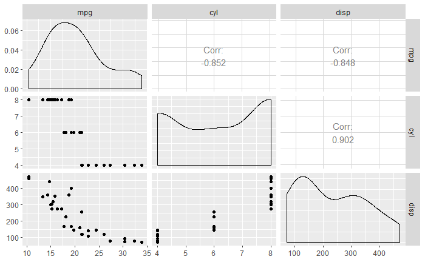

```r
autoplot(task_mtcars, type = 'pairs')
```

### 2.2.3 Predefined tasks

mlr3 ships with a few predefined machine learning tasks. All tasks are stored in an R6 Dictionary (a key-value store) named `mlr_tasks`.

```r
mlr_tasks
```

```
<DictionaryTask> with 9 stored values
Keys: boston_housing, german_credit, iris, mtcars, pima, sonar, spam,
  wine, zoo
```

```r
as.data.table(mlr_tasks)
```

| key | task_type | nrow | ncol | lgl | int | dbl | chr | fct | ord | pxc |
| --- | --- | --- | --- | --- | --- | --- | --- | --- | --- | --- |
| boston_housing | regr | 506 | 19 | 0 | 3 | 13 | 0 | 2 | 0 | 0 |
| german_credit | classif | 1000 | 21 | 0 | 0 | 7 | 0 | 12 | 1 | 0 |
| iris | classif | 150 | 5 | 0 | 0 | 4 | 0 | 0 | 0 | 0 |
| mtcars | regr | 32 | 11 | 0 | 0 | 10 | 0 | 0 | 0 | 0 |
| pima | classif | 768 | 9 | 0 | 0 | 8 | 0 | 0 | 0 | 0 |
| sonar | classif | 208 | 61 | 0 | 0 | 60 | 0 | 0 | 0 | 0 |
| spam | classif | 4601 | 58 | 0 | 0 | 57 | 0 | 0 | 0 | 0 |
| wine | classif | 178 | 14 | 0 | 2 | 11 | 0 | 0 | 0 | 0 |
| zoo | classif | 101 | 17 | 15 | 1 | 0 | 0 | 0 | 0 | 0 |

```r
task_iris = mlr_tasks$get('iris')
print(task_iris)
```

```
<TaskClassif:iris> (150 x 5)
* Target: Species
* Properties: multiclass
* Features (4):
  - dbl (4): Petal.Length, Petal.Width, Sepal.Length, Sepal.Width
```

```r
tsk('iris')
```

```
<TaskClassif:iris> (150 x 5)
* Target: Species
* Properties: multiclass
* Features (4):
  - dbl (4): Petal.Length, Petal.Width, Sepal.Length, Sepal.Width
```

### 2.2.4 Task API

#### 2.2.4.1 Retrieving Data

```r
task_iris$nrow
```

```
[1] 150
```

```r
task_iris$ncol
```

```
[1] 5
```

```r
task_iris$data()
```

| Species | Petal.Length | Petal.Width | Sepal.Length | Sepal.Width |
| --- | --- | --- | --- | --- |
| setosa | 1.4 | 0.2 | 5.1 | 3.5 |
| setosa | 1.4 | 0.2 | 4.9 | 3.0 |
| setosa | 1.3 | 0.2 | 4.7 | 3.2 |
| setosa | 1.5 | 0.2 | 4.6 | 3.1 |
| setosa | 1.4 | 0.2 | 5.0 | 3.6 |
| setosa | 1.7 | 0.4 | 5.4 | 3.9 |
| setosa | 1.4 | 0.3 | 4.6 | 3.4 |
| setosa | 1.5 | 0.2 | 5.0 | 3.4 |
| setosa | 1.4 | 0.2 | 4.4 | 2.9 |
| setosa | 1.5 | 0.1 | 4.9 | 3.1 |

[output cut: 140 more lines]

row_ids as integer

```r
head(task_iris$row_ids)
```

```
[1] 1 2 3 4 5 6
```

`data(rows = c(...))`

```r
task_iris$data(rows = c(1, 51, 101))
```

| Species | Petal.Length | Petal.Width | Sepal.Length | Sepal.Width |
| --- | --- | --- | --- | --- |
| setosa | 1.4 | 0.2 | 5.1 | 3.5 |
| versicolor | 4.7 | 1.4 | 7.0 | 3.2 |
| virginica | 6.0 | 2.5 | 6.3 | 3.3 |

target and feature columns also have unique identifiers, i.e. names. These names are stored in the public slots `$feature_names` and `$target_names`.

```r
task_iris$target_names
```

```
[1] "Species"
```

```r
task_iris$feature_names
```

```
[1] "Petal.Length" "Petal.Width"  "Sepal.Length" "Sepal.Width"
```

```r
task_iris$data(rows = c(1, 51, 101), cols = 'Species')
```

| Species |
| --- |
| setosa |
| versicolor |
| virginica |

To extract the complete data from task, one can simply convert it to a data.table()

```r
task_iris %>% as.data.table()
```

| Species | Petal.Length | Petal.Width | Sepal.Length | Sepal.Width |
| --- | --- | --- | --- | --- |
| setosa | 1.4 | 0.2 | 5.1 | 3.5 |
| setosa | 1.4 | 0.2 | 4.9 | 3.0 |
| setosa | 1.3 | 0.2 | 4.7 | 3.2 |
| setosa | 1.5 | 0.2 | 4.6 | 3.1 |
| setosa | 1.4 | 0.2 | 5.0 | 3.6 |
| setosa | 1.7 | 0.4 | 5.4 | 3.9 |
| setosa | 1.4 | 0.3 | 4.6 | 3.4 |
| setosa | 1.5 | 0.2 | 5.0 | 3.4 |
| setosa | 1.4 | 0.2 | 4.4 | 2.9 |
| setosa | 1.5 | 0.1 | 4.9 | 3.1 |

[output cut: 140 more lines]

```r
task_iris %>% as.data.table() %>% summary()
```

```
       Species    Petal.Length    Petal.Width     Sepal.Length    Sepal.Width
 setosa    :50   Min.   :1.000   Min.   :0.100   Min.   :4.300   Min.   :2.000
 versicolor:50   1st Qu.:1.600   1st Qu.:0.300   1st Qu.:5.100   1st Qu.:2.800
 virginica :50   Median :4.350   Median :1.300   Median :5.800   Median :3.000
                 Mean   :3.758   Mean   :1.199   Mean   :5.843   Mean   :3.057
                 3rd Qu.:5.100   3rd Qu.:1.800   3rd Qu.:6.400   3rd Qu.:3.300
                 Max.   :6.900   Max.   :2.500   Max.   :7.900   Max.   :4.400
```

#### 2.2.4.2 Roles(Rows and Columns)

```r
task_mtcars$col_roles
```

```
$feature
[1] "cyl"  "disp"

$target
[1] "mpg"

$name
character(0)

$order
character(0)

$stratum
character(0)

$group
character(0)

$weight
character(0)
```

To add the row names of `mtcars` as an additional feature, we first add them to the data table and then recreate the task.

```r
# with `keep.rownames`,  data.table stores the row names in an extra column 'rn'

data = as.data.table(mtcars[, 1:3], keep.rownames = TRUE)
data
```

| rn | mpg | cyl | disp |
| --- | --- | --- | --- |
| Mazda RX4 | 21.0 | 6 | 160.0 |
| Mazda RX4 Wag | 21.0 | 6 | 160.0 |
| Datsun 710 | 22.8 | 4 | 108.0 |
| Hornet 4 Drive | 21.4 | 6 | 258.0 |
| Hornet Sportabout | 18.7 | 8 | 360.0 |
| Valiant | 18.1 | 6 | 225.0 |
| Duster 360 | 14.3 | 8 | 360.0 |
| Merc 240D | 24.4 | 4 | 146.7 |
| Merc 230 | 22.8 | 4 | 140.8 |
| Merc 280 | 19.2 | 6 | 167.6 |

[output cut: 22 more lines]

```r
task_mtcars_1 = TaskRegr$new(id = 'cars', backend = data, target = 'mpg')
```

```r
task_mtcars_1$feature_names
```

```
[1] "cyl"  "disp" "rn"
```

```r
task_mtcars_1 %>% as.data.table()
```

| mpg | cyl | disp | rn |
| --- | --- | --- | --- |
| 21.0 | 6 | 160.0 | Mazda RX4 |
| 21.0 | 6 | 160.0 | Mazda RX4 Wag |
| 22.8 | 4 | 108.0 | Datsun 710 |
| 21.4 | 6 | 258.0 | Hornet 4 Drive |
| 18.7 | 8 | 360.0 | Hornet Sportabout |
| 18.1 | 6 | 225.0 | Valiant |
| 14.3 | 8 | 360.0 | Duster 360 |
| 24.4 | 4 | 146.7 | Merc 240D |
| 22.8 | 4 | 140.8 | Merc 230 |
| 19.2 | 6 | 167.6 | Merc 280 |

[output cut: 22 more lines]

We will change the role of the “rn” column and remove it from the set of active features. This is done by simply modifying the field `$col_roles`

```r
# suppported column roles, see ?Task
names(task_mtcars_1$col_roles)
```

```
[1] "feature" "target"  "name"    "order"   "stratum" "group"   "weight"
```

```r
# assign column 'rn' the role 'name'
task_mtcars_1$col_roles$name = 'rn' # use chain /s self in R6 class is chainable.

task_mtcars_1$col_roles
```

```
$feature
[1] "cyl"  "disp" "rn"

$target
[1] "mpg"

$name
[1] "rn"

$order
character(0)

$stratum
character(0)

$group
character(0)

$weight
character(0)
```

```r
# remove 'rn' from role 'feature'
task_mtcars_1$col_roles$feature = setdiff(task_mtcars_1$col_roles$feature, 'rn')
```

```r
task_mtcars_1$feature_names
```

```
[1] "cyl"  "disp"
```

‘rn’ does not appear anymore when we access the data

```r
task_mtcars_1$data(rows = 1:5)
```

| mpg | cyl | disp |
| --- | --- | --- |
| 21.0 | 6 | 160 |
| 21.0 | 6 | 160 |
| 22.8 | 4 | 108 |
| 21.4 | 6 | 258 |
| 18.7 | 8 | 360 |

Changing the role does not change the underlying data. Changing the role only change the view on it.

Row can have two different roles:

1. Role `use`: Rows that are generally available for model fitting (although they may akso be used as test set in resampling). This role is the default role.
2. Role `validation`: Rows that are not used for training. Rows that have missing values iin the target column during task creation are automatically set to the validation role.

#### 2.2.4.3 Task Mutators

`$filter()` subsets the current view based on row ids and`$select()` subsets the view on the data.

```r
task = tsk('iris')
task$select(c('Sepal.Width', 'Sepal.Length'))
task$filter(1:3)
task$head()
```

| Species | Sepal.Length | Sepal.Width |
| --- | --- | --- |
| setosa | 5.1 | 3.5 |
| setosa | 4.9 | 3.0 |
| setosa | 4.7 | 3.2 |

`$rbind()` and `$cbind()` allow to add extra rows and columns to a task.(The original data is not changed).

```r
task$cbind(data.table(foo = letters[1:3]))
task$head()
```

| Species | Sepal.Length | Sepal.Width | foo |
| --- | --- | --- | --- |
| setosa | 5.1 | 3.5 | a |
| setosa | 4.9 | 3.0 | b |
| setosa | 4.7 | 3.2 | c |

### 2.2.5 Plotting Tasks

The `mlr3viz` package provides plotting facilities for many implemented in `mlr3`. all plots are returned as ggplot2 objects which can be easily customized.

- `mlr3viz::autoplot.TaskClassif`

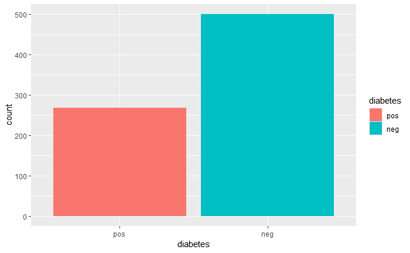

```r
library(mlr3viz)

# get the pima indians task
task = tsk('pima')

# subset task to only use the 3 first features
task$select(head(task$feature_names, 3))

# default plot: class frequencies
autoplot(task)
```

Customizing the ggplot which is made from `autoplot()`

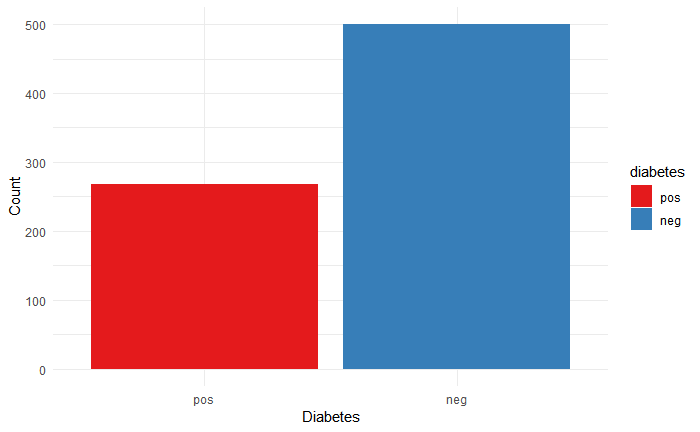

```r
p <- autoplot(task)
p + theme_minimal() +
  labs(x = 'Diabetes', y = 'Count') +
  scale_fill_brewer(palette = 'Set1')
```

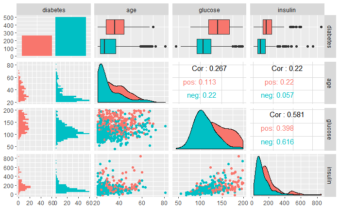

```r
# pairs plot (requires package GGally)
autoplot(task, type = 'pairs')
```

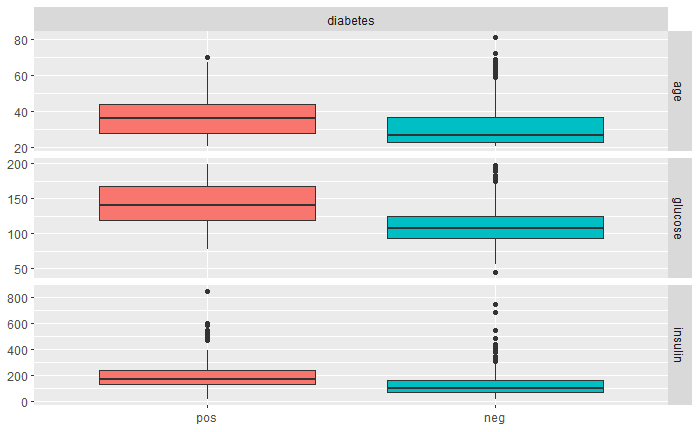

```r
# duo plot requires package GGally)
autoplot(task, type = 'duo')
```

For regression task: `mlr3viz::autoplot.TaskRegr`

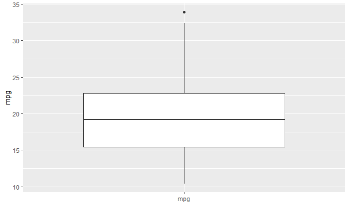

```r
task = tsk('mtcars')
task$select(head(task$feature_names, 3))
autoplot(task)
```

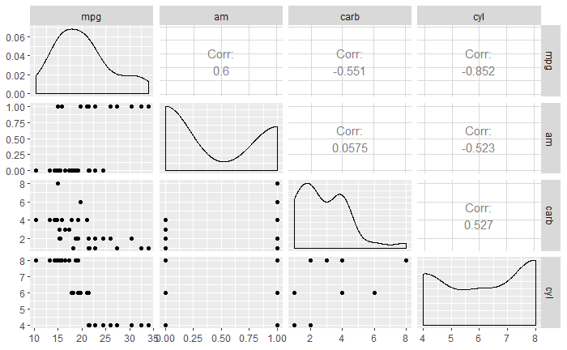

```r
autoplot(task, type = 'pairs')
```

## 2.3 Learners

- mlr_learners_classif.featureless
- mlr_learners_classif.rpart
- mlr_learners_regr.featureless
- mlr_learners_regr.rpart

Some of the most popular learners are connected via the mlr3learners package:

- (penalized) linear and logistic regeression
- k-Nearest Neighbor regeression and classification
- Linear and Quadratic Discriminant Analysis
- Naive Bayes
- Support-Vector machines
- Gradient Boosting
- Random Forest(Regression and Classification)
- Kirging

mlr3learners organization

### 2.3.1 Predefined Learners

```r
mlr_learners
```

```
<DictionaryLearner> with 21 stored values
Keys: classif.debug, classif.featureless, classif.glmnet, classif.kknn,
  classif.lda, classif.log_reg, classif.naive_bayes, classif.qda,
  classif.ranger, classif.rpart, classif.svm, classif.xgboost,
  regr.featureless, regr.glmnet, regr.kknn, regr.km, regr.lm, regr.ranger,
  regr.rpart, regr.svm, regr.xgboost
```

Each learner has the following information:

- feature_types: the type of features the learner can deal with
- packages: the packages required to train a model with this learner and make predictions
- properties: additional properties and capabilities.
  - missing, importance
- predict_types: possible prediction types
  - label(‘response’), probabilities(‘prob’)

```r
learner = mlr_learners$get('classif.rpart')
learner
```

```
<LearnerClassifRpart:classif.rpart>
* Model: -
* Parameters: xval=0
* Packages: rpart
* Predict Type: response
* Feature types: logical, integer, numeric, factor, ordered
* Properties: importance, missings, multiclass, selected_features,
  twoclass, weights
```

The field param_set stores a description of the hyperparameters the learner has, their ranges, defaults and current values

```r
learner$param_set
```

```
ParamSet:
```

| id | class | lower | upper | levels | default | value |
| --- | --- | --- | --- | --- | --- | --- |
| minsplit | ParamInt | 1 | Inf |  |  |  |
| minbucket | ParamInt | 1 | Inf |  |  |  |
| cp | ParamDbl | 0 | 1 |  |  |  |
| maxcompete | ParamInt | 0 | Inf |  |  |  |
| maxsurrogate | ParamInt | 0 | Inf |  |  |  |
| maxdepth | ParamInt | 1 | 30 |  |  |  |
| usesurrogate | ParamInt | 0 | 2 |  |  |  |
| surrogatestyle | ParamInt | 0 | 1 |  |  |  |
| xval | ParamInt | 0 | Inf |  |  |  |

```r
learner$param_set$values = list(cp = .01, xval = 0)
learner
```

```
<LearnerClassifRpart:classif.rpart>
* Model: -
* Parameters: cp=0.01, xval=0
* Packages: rpart
* Predict Type: response
* Feature types: logical, integer, numeric, factor, ordered
* Properties: importance, missings, multiclass, selected_features,
  twoclass, weights
```

Note that this operation just overwrite all previously set parameters. If you just want to add or update hyperparameters, you can use `mlr3misc::insert_named()`

```r
learner$param_set$values = mlr3misc::insert_named(
  learner$param_set$values,
  list(cp = .02, minsplit = 2)
)

learner
```

```
<LearnerClassifRpart:classif.rpart>
* Model: -
* Parameters: cp=0.02, xval=0, minsplit=2
* Packages: rpart
* Predict Type: response
* Feature types: logical, integer, numeric, factor, ordered
* Properties: importance, missings, multiclass, selected_features,
  twoclass, weights
```

This updates `cp` to 0.02, sets `minsplit` to 2 and keeps the previously set parameter `xval`

```r
lrn('classif.rpart', id = 'rp', cp = .001)
```

```
<LearnerClassifRpart:rp>
* Model: -
* Parameters: xval=0, cp=0.001
* Packages: rpart
* Predict Type: response
* Feature types: logical, integer, numeric, factor, ordered
* Properties: importance, missings, multiclass, selected_features,
  twoclass, weights
```

## 2.4 Train and Predict

Training a learner means fitting a model to a given dataset.

### 2.4.1 Creating Task and Learner Objects

1. The classification task:

```r
task = tsk('sonar')
```

2. A learner for the classification tree.

```r
learner = lrn('classif.rpart')
learner
```

```
<LearnerClassifRpart:classif.rpart>
* Model: -
* Parameters: xval=0
* Packages: rpart
* Predict Type: response
* Feature types: logical, integer, numeric, factor, ordered
* Properties: importance, missings, multiclass, selected_features,
  twoclass, weights
```

or

```r
learner = mlr_learners$get('classif.rpart')
learner
```

```
<LearnerClassifRpart:classif.rpart>
* Model: -
* Parameters: xval=0
* Packages: rpart
* Predict Type: response
* Feature types: logical, integer, numeric, factor, ordered
* Properties: importance, missings, multiclass, selected_features,
  twoclass, weights
```

### 2.4.2 Setting up the train/test splits of the data

set the train_set rowids and test_set rowids

```r
train_set = sample(task$nrow, .8*task$nrow)
test_set = setdiff(seq_len(task$nrow), train_set)
```

### 2.4.3 Training the learner

```r
learner$model
```

```r
learner$train(task, row_ids = train_set)
```

```r
learner$model
```

```
n= 166

node), split, n, loss, yval, (yprob)
      * denotes terminal node

 1) root 166 78 M (0.53012048 0.46987952)
   2) V11>=0.19795 93 20 M (0.78494624 0.21505376)
     4) V16< 0.6718 76 10 M (0.86842105 0.13157895)
       8) V34< 0.69215 65  4 M (0.93846154 0.06153846) *
       9) V34>=0.69215 11  5 R (0.45454545 0.54545455) *
     5) V16>=0.6718 17  7 R (0.41176471 0.58823529) *
   3) V11< 0.19795 73 15 R (0.20547945 0.79452055)
     6) V1>=0.0392 7  1 M (0.85714286 0.14285714) *
     7) V1< 0.0392 66  9 R (0.13636364 0.86363636)
      14) V9>=0.1631 7  2 M (0.71428571 0.28571429) *
      15) V9< 0.1631 59  4 R (0.06779661 0.93220339) *
```

### 2.4.4 Predicting

```r
prediction = learner$predict(task, row_ids = test_set)
prediction
```

```
<PredictionClassif> for 42 observations:
```

| row_id | truth | response |
| --- | --- | --- |
| 1 | R | M |
| 2 | R | R |
| 7 | R | M |
| 20 | R | R |
| 21 | R | R |
| 26 | R | R |
| 28 | R | R |
| 29 | R | M |
| 47 | R | R |
| 50 | R | M |

[output cut: 32 more lines]

- The `$predict()` method of the Learner returns a Prediction object. More precisely, a LearnerClassif returns a PredictionClassif object
- A prediction object holds the row ids of the test data, the respective ture label of the target column and the respective predictions. The simplest way to extract this information is by converting the Prediction object to a `data.table`()

```r
prediction %>% as.data.table()
```

| row_id | truth | response |
| --- | --- | --- |
| 1 | R | M |
| 2 | R | R |
| 7 | R | M |
| 20 | R | R |
| 21 | R | R |
| 26 | R | R |
| 28 | R | R |
| 29 | R | M |
| 47 | R | R |
| 50 | R | M |

[output cut: 32 more lines]

For classification, you can also extract the confusion matrix

```r
prediction$confusion
```

```
        truth
response  M  R
       M 14  6
       R  9 13
```

### 2.4.5 Changing the Predict Type

To switch to predicting these probabilities, the `predict_type` field of a `LearnerClassif` must be changed from `response` to `prob` before training.

```r
learner$predict_type = 'prob'

# re-fit the model
learner$train(task, row_ids = train_set)


# rebuild prediction object
prediction = learner$predict(task, row_ids = test_set)
```

The prediction object now contains probabilities for all class labels:

```r
prediction %>% as.data.table()
```

| row_id | truth | response | prob.M | prob.R |
| --- | --- | --- | --- | --- |
| 1 | R | M | 0.71428571 | 0.28571429 |
| 2 | R | R | 0.41176471 | 0.58823529 |
| 7 | R | M | 0.71428571 | 0.28571429 |
| 20 | R | R | 0.41176471 | 0.58823529 |
| 21 | R | R | 0.45454545 | 0.54545455 |
| 26 | R | R | 0.06779661 | 0.93220339 |
| 28 | R | R | 0.06779661 | 0.93220339 |
| 29 | R | M | 0.93846154 | 0.06153846 |
| 47 | R | R | 0.41176471 | 0.58823529 |
| 50 | R | M | 0.93846154 | 0.06153846 |

[output cut: 32 more lines]

Directly access the predicted labels:

```r
prediction$response
```

```
 [1] M R M R R R R M R M R R M R R R R M R R M R R R M M R M R R M M M R M R M M M M
[41] M M
Levels: M R
```

Directly access the matrix of probabilities:

```r
prediction$prob %>% head
```

```
              M         R
[1,] 0.71428571 0.2857143
[2,] 0.41176471 0.5882353
[3,] 0.71428571 0.2857143
[4,] 0.41176471 0.5882353
[5,] 0.45454545 0.5454545
[6,] 0.06779661 0.9322034
```

Analogously to predicting probabilities, many regression learners support the extraction of standard error estimates by setting the predict type to ‘se’

### 2.4.6. Plotting Predictions

`mlr3viz` provides a `autoplot()` method for Prediction objects. autoplot.PredictionClassif(), autoplot.PredictionClassif()

```r
library("mlr3viz")

task = tsk("sonar")
task
```

```
<TaskClassif:sonar> (208 x 61)
* Target: Class
* Properties: twoclass
* Features (60):
  - dbl (60): V1, V10, V11, V12, V13, V14, V15, V16, V17, V18, V19, V2,
    V20, V21, V22, V23, V24, V25, V26, V27, V28, V29, V3, V30, V31, V32,
    V33, V34, V35, V36, V37, V38, V39, V4, V40, V41, V42, V43, V44, V45,
    V46, V47, V48, V49, V5, V50, V51, V52, V53, V54, V55, V56, V57, V58,
    V59, V6, V60, V7, V8, V9
```

```r
learner = lrn('classif.rpart', predict_type = 'prob')
learner
```

```
<LearnerClassifRpart:classif.rpart>
* Model: -
* Parameters: xval=0
* Packages: rpart
* Predict Type: prob
* Feature types: logical, integer, numeric, factor, ordered
* Properties: importance, missings, multiclass, selected_features,
  twoclass, weights
```

```r
train_set = sample(task$nrow, .8*task$nrow)
test_set = setdiff(seq_len(task$nrow), train_set)
```

```r
learner$train(task, row_ids = train_set)
```

```r
prediction = learner$predict(task, row_ids = test_set)
```

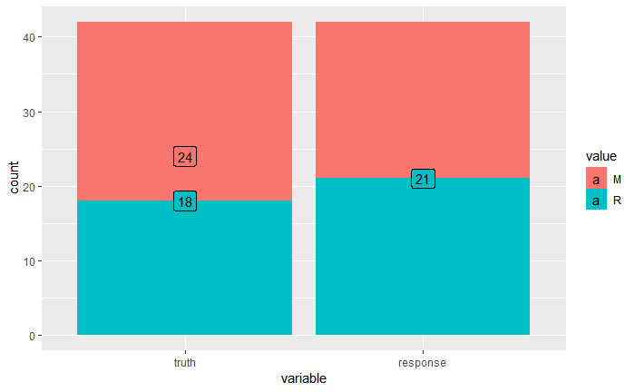

```r
autoplot(prediction)
```

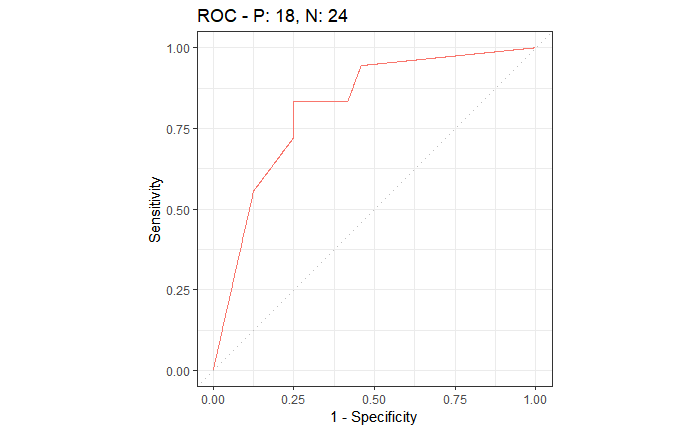

```r
autoplot(prediction, type = 'roc')
```

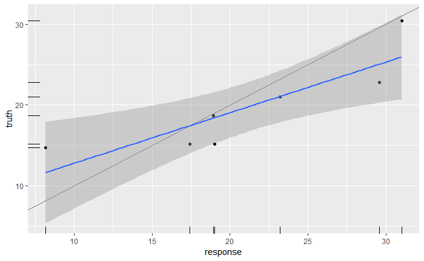

```r
library("mlr3viz")
library("mlr3learners")


local({ # we do this locally to not overwrite the objects from previous chunks
  task = tsk("mtcars")
  train_set = sample(task$nrow, .8*task$nrow)
  test_set = setdiff(seq_len(task$nrow), train_set)
  learner = lrn("regr.lm")
  learner$train(task, row_ids = train_set)
  prediction = learner$predict(task, row_ids = test_set)
  autoplot(prediction)
})
```

### 2.4.7 Performance assessment

```r
mlr_measures
```

```
<DictionaryMeasure> with 51 stored values
Keys: classif.acc, classif.auc, classif.bacc, classif.ce, classif.costs,
  classif.dor, classif.fbeta, classif.fdr, classif.fn, classif.fnr,
  classif.fomr, classif.fp, classif.fpr, classif.logloss, classif.mcc,
  classif.npv, classif.ppv, classif.precision, classif.recall,
  classif.sensitivity, classif.specificity, classif.tn, classif.tnr,
  classif.tp, classif.tpr, debug, oob_error, regr.bias, regr.ktau,
  regr.mae, regr.mape, regr.maxae, regr.medae, regr.medse, regr.mse,
  regr.msle, regr.pbias, regr.rae, regr.rmse, regr.rmsle, regr.rrse,
  regr.rse, regr.rsq, regr.sae, regr.smape, regr.srho, regr.sse,
  selected_features, time_both, time_predict, time_train
```

```r
measure = msr('classif.acc')
prediction$score(measure)
```

```
classif.acc
  0.7857143
```

## 2.5 Resampling

mlr3 entails 6 predefined resampling strategies. - Cross-validation - Leave-one-out cross validation - Repeated cross validation - Out of bag bootstrap and other variants(e.g. b632) - Monte-Carlo cross-validation - Hold out

### 2.5.1 Settings

```r
task = tsk('iris')
learner = lrn('classif.rpart')
```

[output not shown]

mlr3spatiotemporal

```r
mlr_resamplings$get('holdout')
```

```
<ResamplingHoldout> with 1 iterations
* Instantiated: FALSE
* Parameters: ratio=0.6667
```

```r
rsmp('holdout')
```

```
<ResamplingHoldout> with 1 iterations
* Instantiated: FALSE
* Parameters: ratio=0.6667
```

```r
resampling = rsmp('holdout')
resampling
```

```
<ResamplingHoldout> with 1 iterations
* Instantiated: FALSE
* Parameters: ratio=0.6667
```

Note that the $is_instantiated field is set to FALSE. This means we did not actually apply the strategy on a dataset yet.

By default we get a .66/.33 split of the data. There are two ways in which the ratio can be changed:

1. Overwriting the slot in `$param_set$values` using a named list

```r
resampling
```

[output not shown]

2. Specifying the resampling parameters directly during construction:

```r
rsmp('holdout', ratio = .8)
```

```
<ResamplingHoldout> with 1 iterations
* Instantiated: FALSE
* Parameters: ratio=0.8
```

### 2.5.2 Instantiation

```r
resampling = rsmp('cv', folds = 3L)
resampling$instantiate(task)
```

```r
resampling$iters
```

```
[1] 3
```

```r
resampling$test_set(1) %>% str()
```

```
 int [1:50] 3 5 6 11 16 18 19 20 23 26 ...
```

```r
resampling$test_set(2) %>% str()
```

```
 int [1:50] 2 4 7 14 15 21 27 35 37 38 ...
```

```r
resampling$test_set(3) %>% str()
```

```
 int [1:50] 1 8 9 10 12 13 17 22 24 25 ...
```

### 2.5.3 Execution

With a `Task`, a `Learner` and a `Resampling` object we can call `resample()`, which fits the learner to the task at hand according to the given resampling strategy. This in turn creates a `ResampleResul`t object.

```r
task = tsk('pima')
learner = lrn('classif.rpart', maxdepth = 3, predict_type = 'prob')
resampling = rsmp("cv", folds = 3L)
```

```r
rr = resample(task, learner, resampling, store_models = TRUE)
```

```
INFO  [19:37:43.972] Applying learner 'classif.rpart' on task 'pima' (iter 1/3)
INFO  [19:37:44.060] Applying learner 'classif.rpart' on task 'pima' (iter 2/3)
INFO  [19:37:44.108] Applying learner 'classif.rpart' on task 'pima' (iter 3/3)
```

```r
rr
```

```
<ResampleResult> of 3 iterations
* Task: pima
* Learner: classif.rpart
* Warnings: 0 in 0 iterations
* Errors: 0 in 0 iterations
```

Calculate the average performance across all resampling iterations:

```r
rr$aggregate(msr('classif.ce'))
```

```
classif.ce
 0.2486979
```

Extract the performance for the individual resampling iterations

| task | task_id | learner | learner_id | resampling | resampling_id | iteration | prediction | classif.ce |
| --- | --- | --- | --- | --- | --- | --- | --- | --- |
|  | pima |  | classif.rpart |  | cv | 1 |  | 0.2617188 |
|  | pima |  | classif.rpart |  | cv | 2 |  | 0.2226562 |
|  | pima |  | classif.rpart |  | cv | 3 |  | 0.2617188 |

| iteration | msg |
| --- | --- |

| iteration | msg |
| --- | --- |

Extract and inspect the resampling splits:

```r
rr$resampling
```

```
<ResamplingCV> with 3 iterations
* Instantiated: TRUE
* Parameters: folds=3
```

```r
rr$resampling$iters
```

```
[1] 3
```

```r
rr$resampling$train_set(1) %>% str
```

```
 int [1:512] 1 3 8 9 12 13 15 21 23 24 ...
```

Retrieve the learner of a specific iteration and inspect it:

```r
lrn = rr$learners[[1]]
lrn$model
```

```
n= 512

node), split, n, loss, yval, (yprob)
      * denotes terminal node

 1) root 512 181 neg (0.3535156 0.6464844)
   2) glucose>=143.5 112  29 pos (0.7410714 0.2589286)
     4) glucose>=157.5 69  10 pos (0.8550725 0.1449275) *
     5) glucose< 157.5 43  19 pos (0.5581395 0.4418605)
      10) age>=35 22   5 pos (0.7727273 0.2272727) *
      11) age< 35 21   7 neg (0.3333333 0.6666667) *
   3) glucose< 143.5 400  98 neg (0.2450000 0.7550000) *
```

Extract the predictions:

```r
rr$prediction()
```

```
<PredictionClassif> for 768 observations:
```

| row_id | truth | response | prob.pos | prob.neg |
| --- | --- | --- | --- | --- |
| 5 | pos | neg | 0.2450000 | 0.7550000 |
| 6 | neg | neg | 0.2450000 | 0.7550000 |
| 11 | neg | neg | 0.2450000 | 0.7550000 |
| 14 | pos | pos | 0.8550725 | 0.1449275 |
| 18 | pos | neg | 0.2450000 | 0.7550000 |
| 25 | pos | neg | 0.2450000 | 0.7550000 |
| 26 | pos | neg | 0.2450000 | 0.7550000 |
| 30 | neg | neg | 0.2450000 | 0.7550000 |
| 31 | neg | neg | 0.2450000 | 0.7550000 |
| 34 | neg | neg | 0.2450000 | 0.7550000 |

[output cut: 758 more lines]

```r
rr$predictions()[[1]] # prediction of first resampling iteration
```

```
<PredictionClassif> for 256 observations:
```

| row_id | truth | response | prob.pos | prob.neg |
| --- | --- | --- | --- | --- |
| 5 | pos | neg | 0.2450000 | 0.7550000 |
| 6 | neg | neg | 0.2450000 | 0.7550000 |
| 11 | neg | neg | 0.2450000 | 0.7550000 |
| 14 | pos | pos | 0.8550725 | 0.1449275 |
| 18 | pos | neg | 0.2450000 | 0.7550000 |
| 25 | pos | neg | 0.2450000 | 0.7550000 |
| 26 | pos | neg | 0.2450000 | 0.7550000 |
| 30 | neg | neg | 0.2450000 | 0.7550000 |
| 31 | neg | neg | 0.2450000 | 0.7550000 |
| 34 | neg | neg | 0.2450000 | 0.7550000 |

[output cut: 246 more lines]

### 2.5.4 Custom resampling

A manual resampling instance can be created using the “custom” template.

```r
resampling = rsmp('custom')
resampling$instantiate(task,
                       train = list(c(1:10, 51:60, 101:110)),
                       test = list(c(11:20, 61:70, 111:120))
                       )
resampling$iters
```

```
[1] 1
```

```r
resampling$train_set(1)
```

```
 [1]   1   2   3   4   5   6   7   8   9  10  51  52  53  54  55  56  57  58  59  60
[21] 101 102 103 104 105 106 107 108 109 110
```

```r
resampling$test_set(1)
```

```
 [1]  11  12  13  14  15  16  17  18  19  20  61  62  63  64  65  66  67  68  69  70
[21] 111 112 113 114 115 116 117 118 119 120
```

2.5.5 Plotting Resample Results

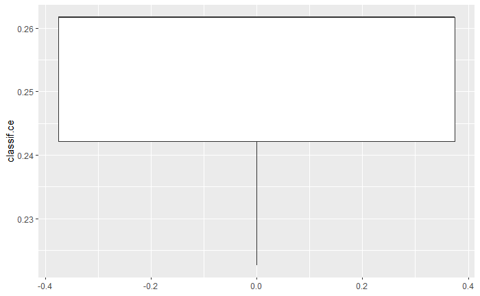

```r
autoplot(rr)
```

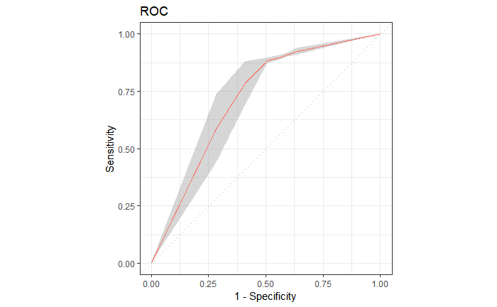

## 2.6 Benchmarking

Comparing the performance of different learners on multiple tasks and/or different resampling schemes is a common task. This operation is usually referred to as “benchmarking” in the field of machine-learning.

### 2.6.1 Design Creation

By “design” we essentially mean the matrix of settings you want to execute.

A “design” consists of unique combinations of Task, Learner and Resampling triplets.

[output not shown]

```r
bmr = benchmark(design)
```

```
INFO  [20:19:26.112] Benchmark with 2 resampling iterations
INFO  [20:19:26.130] Applying learner 'classif.rpart' on task 'iris' (iter 1/1)
INFO  [20:19:26.169] Applying learner 'classif.featureless' on task 'iris' (iter 1/1)
INFO  [20:19:26.197] Finished benchmark
```

```r
bmr
```

```
<BenchmarkResult> of 2 rows with 2 resampling runs
```

| nr | task_id | learner_id | resampling_id | iters | warnings | errors |
| --- | --- | --- | --- | --- | --- | --- |
| 1 | iris | classif.rpart | holdout | 1 | 0 | 0 |
| 2 | iris | classif.featureless | holdout | 1 | 0 | 0 |

If you create the design manually, even if the same task is used multiple times, the train/test splits will be different for each row of the design if you do not manually instantiate the resampling before creating the design.

```r
tasks
```

```
[[1]]
<TaskClassif:german_credit> (1000 x 21)
* Target: credit_risk
* Properties: twoclass
* Features (20):
  - fct (12): credit_history, foreign_worker, housing, job, other_debtors,
    other_installment_plans, personal_status_sex, property, purpose,
    savings, status, telephone
  - dbl (7): age, amount, duration, installment_rate, number_credits,
    people_liable, present_residence
  - ord (1): employment_duration

[[2]]
<TaskClassif:sonar> (208 x 61)
* Target: Class
* Properties: twoclass
* Features (60):
  - dbl (60): V1, V10, V11, V12, V13, V14, V15, V16, V17, V18, V19, V2,
    V20, V21, V22, V23, V24, V25, V26, V27, V28, V29, V3, V30, V31, V32,
    V33, V34, V35, V36, V37, V38, V39, V4, V40, V41, V42, V43, V44, V45,
    V46, V47, V48, V49, V5, V50, V51, V52, V53, V54, V55, V56, V57, V58,
    V59, V6, V60, V7, V8, V9
```

```r
# get some learners and for all learners
# * predict prob
# * predict also on the training set

# install.packages('kknn')

learners = c('classif.featureless', 'classif.rpart', 'classif.ranger', 'classif.kknn')
learners = lapply(learners,
                  lrn,
                  predict_type = 'prob',
                  predict_sets = c('train', 'test')
                  )
```

```r
# Create a BenchmarkDesign object
design = benchmark_grid(tasks, learners, resamplings)

design
```

[output not shown]

### 2.6.2 Execution and Aggregation of Results

```r
# execute the benchmark
bmr = benchmark(design)
```

```
INFO  [20:46:37.844] Benchmark with 24 resampling iterations
INFO  [20:46:37.863] Applying learner 'classif.featureless' on task 'german_credit' (iter 1/3)
INFO  [20:46:37.975] Applying learner 'classif.featureless' on task 'german_credit' (iter 2/3)
INFO  [20:46:38.023] Applying learner 'classif.featureless' on task 'german_credit' (iter 3/3)
INFO  [20:46:38.064] Applying learner 'classif.rpart' on task 'german_credit' (iter 1/3)
INFO  [20:46:38.143] Applying learner 'classif.rpart' on task 'german_credit' (iter 2/3)
INFO  [20:46:38.218] Applying learner 'classif.rpart' on task 'german_credit' (iter 3/3)
INFO  [20:46:38.304] Applying learner 'classif.ranger' on task 'german_credit' (iter 1/3)
INFO  [20:46:39.389] Applying learner 'classif.ranger' on task 'german_credit' (iter 2/3)
INFO  [20:46:39.777] Applying learner 'classif.ranger' on task 'german_credit' (iter 3/3)
INFO  [20:46:40.115] Applying learner 'classif.kknn' on task 'german_credit' (iter 1/3)
```

```
INFO  [20:46:40.856] Applying learner 'classif.kknn' on task 'german_credit' (iter 2/3)
```

```
INFO  [20:46:41.064] Applying learner 'classif.kknn' on task 'german_credit' (iter 3/3)
```

```
INFO  [20:46:41.301] Applying learner 'classif.featureless' on task 'sonar' (iter 1/3)
INFO  [20:46:41.335] Applying learner 'classif.featureless' on task 'sonar' (iter 2/3)
INFO  [20:46:41.372] Applying learner 'classif.featureless' on task 'sonar' (iter 3/3)
INFO  [20:46:41.412] Applying learner 'classif.rpart' on task 'sonar' (iter 1/3)
INFO  [20:46:41.497] Applying learner 'classif.rpart' on task 'sonar' (iter 2/3)
INFO  [20:46:41.577] Applying learner 'classif.rpart' on task 'sonar' (iter 3/3)
INFO  [20:46:41.671] Applying learner 'classif.ranger' on task 'sonar' (iter 1/3)
INFO  [20:46:41.835] Applying learner 'classif.ranger' on task 'sonar' (iter 2/3)
INFO  [20:46:41.996] Applying learner 'classif.ranger' on task 'sonar' (iter 3/3)
INFO  [20:46:42.144] Applying learner 'classif.kknn' on task 'sonar' (iter 1/3)
```

```
INFO  [20:46:42.307] Applying learner 'classif.kknn' on task 'sonar' (iter 2/3)
```

```
INFO  [20:46:42.445] Applying learner 'classif.kknn' on task 'sonar' (iter 3/3)
```

```
INFO  [20:46:42.633] Finished benchmark
```

```r
# measures:

# * auc on training
# * auc on test

measures = list(
  msr('classif.auc', id = 'auc_train', predict_sets = 'train'),
  msr('classif.auc', id = 'auc_test')
)
```

```r
bmr$aggregate(measures)
```

| nr | resample_result | task_id | learner_id | resampling_id | iters | auc_train | auc_test |
| --- | --- | --- | --- | --- | --- | --- | --- |
| 1 |  | german_credit | classif.featureless | cv | 3 | 0.5000000 | 0.5000000 |
| 2 |  | german_credit | classif.rpart | cv | 3 | 0.7955625 | 0.7247169 |
| 3 |  | german_credit | classif.ranger | cv | 3 | 0.9987140 | 0.7999112 |
| 4 |  | german_credit | classif.kknn | cv | 3 | 0.9874025 | 0.7185591 |
| 5 |  | sonar | classif.featureless | cv | 3 | 0.5000000 | 0.5000000 |
| 6 |  | sonar | classif.rpart | cv | 3 | 0.9209887 | 0.7612374 |
| 7 |  | sonar | classif.ranger | cv | 3 | 1.0000000 | 0.9102396 |
| 8 |  | sonar | classif.kknn | cv | 3 | 0.9965307 | 0.9311471 |

Subsequently, we can aggregate the results further. For example, we might be interested which learner performed best over all tasks simultaneously. Simply aggregating the performances with the mean is usually not statistically sound. Instead, we calculate the rank statistic for each learner grouped by task.

```r
tab = bmr$aggregate(measures)
tab
```

| nr | resample_result | task_id | learner_id | resampling_id | iters | auc_train | auc_test |
| --- | --- | --- | --- | --- | --- | --- | --- |
| 1 |  | german_credit | classif.featureless | cv | 3 | 0.5000000 | 0.5000000 |
| 2 |  | german_credit | classif.rpart | cv | 3 | 0.7955625 | 0.7247169 |
| 3 |  | german_credit | classif.ranger | cv | 3 | 0.9987140 | 0.7999112 |
| 4 |  | german_credit | classif.kknn | cv | 3 | 0.9874025 | 0.7185591 |
| 5 |  | sonar | classif.featureless | cv | 3 | 0.5000000 | 0.5000000 |
| 6 |  | sonar | classif.rpart | cv | 3 | 0.9209887 | 0.7612374 |
| 7 |  | sonar | classif.ranger | cv | 3 | 1.0000000 | 0.9102396 |
| 8 |  | sonar | classif.kknn | cv | 3 | 0.9965307 | 0.9311471 |

Then the calculated ranks grouped by learner are aggregated with data.table. Since the AUC needs to be maximized, we multiply with `−1` so that the best learner gets a rank of `1`.

```r
# group by levels of task_id, return colunms:
# - learner_id
# - rank of col `-auc_train`
# - rank of col `-auc_test`

# used by data.table() grammer.
ranks = tab[, .(learner_id, rank_train = rank(-auc_train), rank_test = rank(-auc_test)), by = task_id]
```

| task_id | learner_id | rank_train | rank_test |
| --- | --- | --- | --- |
| german_credit | classif.featureless | 4 | 4 |
| german_credit | classif.rpart | 3 | 2 |
| german_credit | classif.ranger | 1 | 1 |
| german_credit | classif.kknn | 2 | 3 |
| sonar | classif.featureless | 4 | 4 |
| sonar | classif.rpart | 3 | 3 |
| sonar | classif.ranger | 1 | 2 |
| sonar | classif.kknn | 2 | 1 |

```r
# group by levels of learner_id, return columns
# -mean rank of col `rank_train`
# -mean rank of col `rank_test`

ranks = ranks[, .(mrank_train = mean(rank_train), mrank_test = mean(rank_test)),
              by = learner_id]

ranks
```

| learner_id | mrank_train | mrank_test |
| --- | --- | --- |
| classif.featureless | 4 | 4.0 |
| classif.rpart | 3 | 2.5 |
| classif.ranger | 1 | 1.5 |
| classif.kknn | 2 | 2.0 |

```r
ranks[order(mrank_test)]
```

| learner_id | mrank_train | mrank_test |
| --- | --- | --- |
| classif.ranger | 1 | 1.5 |
| classif.kknn | 2 | 2.0 |
| classif.rpart | 3 | 2.5 |
| classif.featureless | 4 | 4.0 |

### 2.6.3 Plotting Benchmarking Results

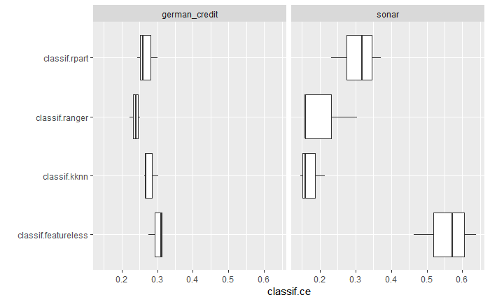

```r
autoplot(bmr) + coord_flip()
```

We can also plot ROC curves. To do so, we first need to filter the BenchmarkResult to only contain a single Task:

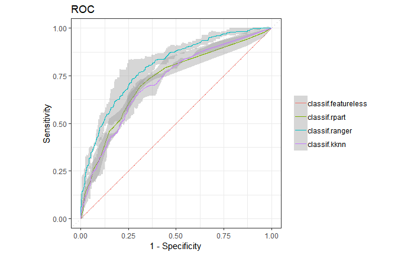

```r
autoplot(bmr$clone()$filter(task_id = "german_credit"), type = "roc")
```

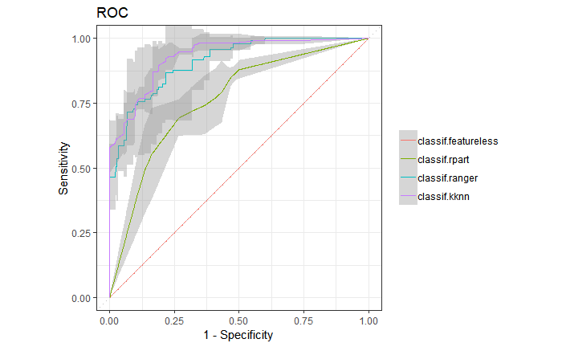

```r
autoplot(bmr$clone()$filter(task_id = "sonar"), type = "roc")
```

### 2.6.4 Extracting ResampleResults

A BenchmarkResult object is essentially a collection of multiple ResampleResult objects. As these are stored in a column of the aggregated data.table(), we can easily extract them:

```r
tab = bmr$aggregate(measures)
rr = tab[task_id == 'sonar' & learner_id == 'classif.ranger']$resample_result[[1]]
rr
```

```
<ResampleResult> of 3 iterations
* Task: sonar
* Learner: classif.ranger
* Warnings: 0 in 0 iterations
* Errors: 0 in 0 iterations
```

```r
measure = msr('classif.auc')
rr$aggregate(measure)
```

```
classif.auc
  0.9102396
```

```r
# get the iteration with worst AUC
perf = rr$score(measure)
i = which.min(perf$classif.auc)
```

```r
rr$learners[[i]]
```

```
<LearnerClassifRanger:classif.ranger>
* Model: -
* Parameters: list()
* Packages: ranger
* Predict Type: prob
* Feature types: logical, integer, numeric, character, factor, ordered
* Properties: importance, multiclass, oob_error, twoclass, weights
```

```r
rr$resampling$train_set(i) %>% head()
```

```
[1]  1  4  8 10 13 17
```

### Converting and Merging ResampleResults

It is also possible to cast a single ResampleResult to a BenchmarkResult using the converter `as_benchmark_result()`.

```r
resampling
```

```
<ResamplingHoldout> with 1 iterations
* Instantiated: TRUE
* Parameters: ratio=0.6667
```

```r
rr1
```

```
<ResampleResult> of 1 iterations
* Task: iris
* Learner: classif.rpart
* Warnings: 0 in 0 iterations
* Errors: 0 in 0 iterations
```

```r
# Cast both ResampleResult to BenchmarkResults
bmr1 = as_benchmark_result(rr1)
bmr2 = as_benchmark_result(rr2)
```

```r
# Merge 2nd BMR into the first BMR
bmr1$combine(bmr2)
```

```r
bmr1
```

```
<BenchmarkResult> of 2 rows with 2 resampling runs
```

| nr | task_id | learner_id | resampling_id | iters | warnings | errors |
| --- | --- | --- | --- | --- | --- | --- |
| 1 | iris | classif.rpart | holdout | 1 | 0 | 0 |
| 2 | iris | classif.featureless | holdout | 1 | 0 | 0 |

## 2.7 Bianary classification

For such binary target variables, you can specify the positive class within the classification task object during task creation. If not explicitly set during construction, the positive class defaults to the first level of the target variable.

```r
# during construction
data("Sonar", package = "mlbench")
task = TaskClassif$new(id = "Sonar", Sonar, target = "Class", positive = "R")
```

```r
# switch positive class to level "M"
task$positive = "M"
```

### 2.7.1 ROC Curve and Thresholds

```r
learner = lrn("classif.rpart", predict_type = "prob")

resampling = rsmp('holdout')
resampling$instantiate(task)

train_idx = resampling$train_set(1)
test_idx = resampling$test_set(1)

rr = resample(task, learner, resampling, store_models = T)
```

```
INFO  [22:18:29.301] Applying learner 'classif.rpart' on task 'Sonar' (iter 1/1)
```

```r
learner$train(task, row_ids = train_idx)

pred = learner$predict(task, row_ids = test_idx)

C = pred$confusion

C
```

```
        truth
response  M  R
       M 24 10
       R 12 23
```